# Predicting Capital Bikeshare User-type, October 2024

This model shows a substantial reduction in deviance (40574) for 12 degrees of freedom with a p-value essentially equal to zero. We reject H0 and conclude the model with predictors fits the data significantly better than the null model.

```r
predicted_probs <- predict(riderLogit10, type = "response")

predicted_classes <- ifelse(predicted_probs > 0.5, "member", "casual")
predicted_classes <- factor(predicted_classes, levels = c("member", "casual"))
actual_classes <- factor(capital_bikeshare_clean$member_casual, levels = c("member", "casual"))

conf_matrix <- confusionMatrix(predicted_classes, actual_classes)

print(conf_matrix)
```

```
## Confusion Matrix and Statistics
##
##           Reference
## Prediction member casual
##     member 458581 199694
##     casual  16424  29244
##
##                Accuracy : 0.693
##                  95% CI : (0.692, 0.694)
##     No Information Rate : 0.675
##     P-Value [Acc > NIR] : <2e-16
##
##                   Kappa : 0.118
##
##  Mcnemar's Test P-Value : <2e-16
##
##             Sensitivity : 0.965
##             Specificity : 0.128
##          Pos Pred Value : 0.697
##          Neg Pred Value : 0.640
##              Prevalence : 0.675
##          Detection Rate : 0.651
##    Detection Prevalence : 0.935
##       Balanced Accuracy : 0.547
##
##        'Positive' Class : member
##
```

```r
accuracy <- conf_matrix$overall["Accuracy"]
print(paste("Accuracy:", round(accuracy, 4)))
```

```
## [1] "Accuracy: 0.693"
```

*Confusion Matrix and Accuracy Tests* This model is approximately 70% accurate, which is less than the 80% target but decent considering the data for this month is moderately skewed toward members. The No Information Rate (NIR) is 0.675 or 67.5%, which is the accuracy of a naive model always predicting the majority class - this model is statistically significantly better than the NIR. However the Kappa is low, suggesting limited improvement over guessing and Mcnemar’s test indicates the model misclassifies disporportionately.Not surprisingly, this model is very sensitive (very good at identifying members), but not very specific (not good at identifying casual riders).

```r
predicted_probs <- predict(riderLogit10, type = "response")

predicted_classes <- ifelse(predicted_probs > 0.61, "member", "casual")
predicted_classes <- factor(predicted_classes, levels = c("member", "casual"))
actual_classes <- factor(capital_bikeshare_clean$member_casual, levels = c("member", "casual"))

conf_matrix <- confusionMatrix(predicted_classes, actual_classes)

print(conf_matrix)
```

```
## Confusion Matrix and Statistics
##
##           Reference
## Prediction member casual
##     member 411492 162584
##     casual  63513  66354
##
##                Accuracy : 0.679
##                  95% CI : (0.678, 0.68)
##     No Information Rate : 0.675
##     P-Value [Acc > NIR] : 2.33e-13
##
##                   Kappa : 0.176
##
##  Mcnemar's Test P-Value : < 2e-16
##
##             Sensitivity : 0.866
##             Specificity : 0.290
##          Pos Pred Value : 0.717
##          Neg Pred Value : 0.511
##              Prevalence : 0.675
##          Detection Rate : 0.585
##    Detection Prevalence : 0.816
##       Balanced Accuracy : 0.578
##
##        'Positive' Class : member
##
```

```r
accuracy <- conf_matrix$overall["Accuracy"]
print(paste("Accuracy:", round(accuracy, 4)))
```

```
## [1] "Accuracy: 0.6788"
```

*Confusion Matrix and Accuracy Test with Increased Cutoff* To improve sensitivity and specificity, we changed the cutoff to 0.61 (increased from 0.5). This reduced the sensitivity from 0.965 to 0.866, increased the specificity from 0.128 to 0.290, and only minimally reduced the accuracy from 0.693 to 0.679. At the 0.61 cutoff, this model is still statistically better than the NIR; at 0.62 it is not, so 0.61 is the likely the best cutoff.

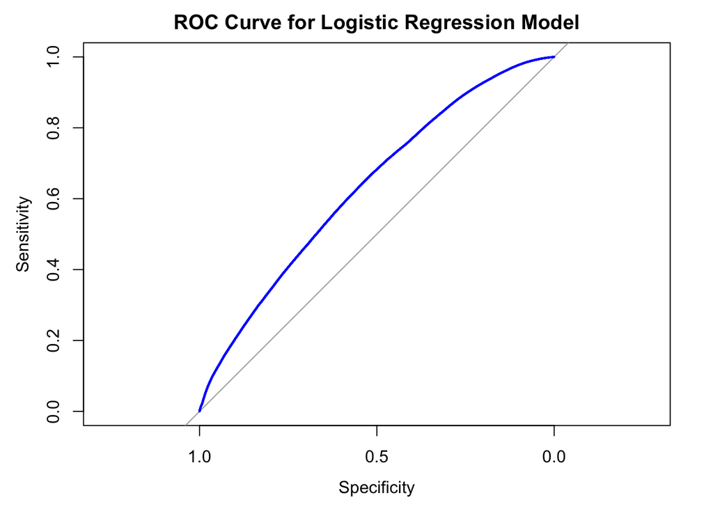

```r
predicted_probs10 <- predict(riderLogit10, newdata = capital_bikeshare_clean, type = "response")
roc_curve10 <- roc(response = capital_bikeshare_clean$member_casual, predicted_probs10, levels = c("casual", "member"))
plot(roc_curve10, main = "ROC Curve for Logistic Regression Model", col = "blue", lwd = 2)
```

```r
auc_value10 <- auc(roc_curve10)
print(paste("AUC (ModelMetrics):", round(auc_value10, 4)))
```

```
## [1] "AUC (ModelMetrics): 0.6337"
```

*Reciever Operating Characteristic (ROC) Curve and Area Under the Curve (AUC)* The AUC of the model is 0.6337 which is certainly below the target of 0.8, but still better than the null model.

```r
riderLogit10pr2 = pR2(riderLogit10)
```

```
## fitting null model for pseudo-r2
```

```r
riderLogit10pr2
```

```
##       llh   llhNull        G2  McFadden      r2ML      r2CU
## -4.24e+05 -4.44e+05  4.06e+04  4.57e-02  5.60e-02  7.81e-02
```

*Measures of Pseudo R-square including McFadden’s* The McFadden’s R-square is 0.0457 or (4.57%), which indicates this model explains a small but meaningful portion of variation in outcome compared to the null model.

# Conclusions

Riders are overall more likely to be members. Electric bikes and longer rides reduce the odds, though less so if the longer ride is on an electric bike. Longer distances increase the odds of membership, while weekends reduce the odds. Morning rides strongly increase the odds of membership.

While the decision tree was not highly accurate for predicting member type (~31%), the logistic regression model was approximately 70% accurate.This is a reasonable result given the small number of variables given.

Additionally, this dataset is a small snapshot of users and may not accurately reflect the true distribution of users over the course of the year. In order to accommodate the imbalance in the classes, we could create a subset sample that oversamples the casual riders (the minority class) and undersamples the member riders (the majority class), to create a balanced sample for the the analysis. However we did not feel the imbalance was so extreme that this would be necessary. Additionally, we suspect that if an entire year were sampled, the classes may be more balanced. The results of the study by Sadeghvazi et al. (2024) were likely different, and even opposite, from ours because they examined data from an entire year of usage.

There are many additional factors that likely affect class distribution and bike usage including time of year/season, weather, sunset times. Capital Bikeshare usage is also likely affected by geospatial factors like distance between home and a docking station, and distance to other forms of public transit. Finally, socioeconomic factors also likely have a significant impact. Future research might examine an integration of these variables into the current model for more accurate outcomes.

# References

Bicycle-sharing systems. (2024, November 7). In *Wikipedia*. https://en.wikipedia.org/wiki/Bicycle-sharing_system

*About Company & History*. (n.d). Capital Bikeshare. Retrieved December 13, 2024, from https://ride.capitalbikeshare.com/about

Sadeghvaziri, E., Javid, R., Constantin, N. (2024). Analyzing the Influential Factors and Dynamics of Bikeshare Utilization in Washington, DC. *International Conference on Transportation and Development*. https://doi.org/10.1061/9780784485521.028

Tushar, M.D., & Buehler, R. (2024). Bikeshare–Metrorail Integration in Washington, D.C.: What are the Characteristics of Neighborhoods that Encourage Capital Bikeshare Trips to and from the Metrorail? *Journal of the Transportation Research Board, 2678*(10). https://doi.org/10.1177/03611981241233275